# Crop Timing Visualization

# **Central farm location (red dot)**

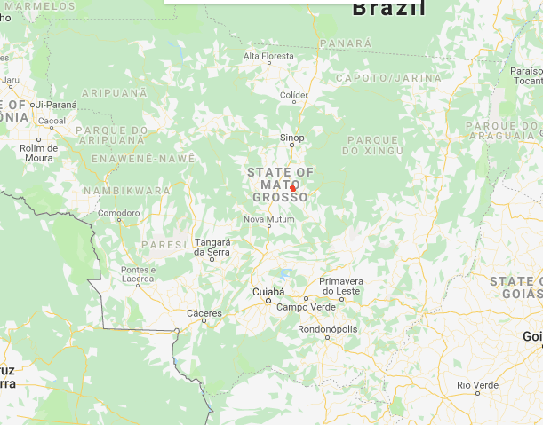

# **Central farm cropping**

The central farm has both double and single cropped pixels. Double cropped pixels dominate and it appears that SC and DC were planted/harvested at the same time. Perhaps the whole farm is DC and parts were misclassified as SC?

**Double cropped pixels in central farm in 2017:**

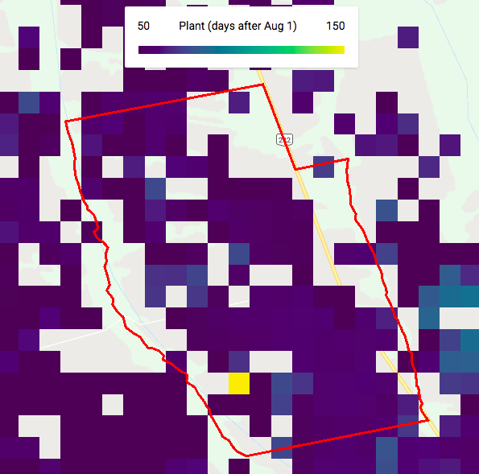

**Single cropped pixels in central farm in 2017:**

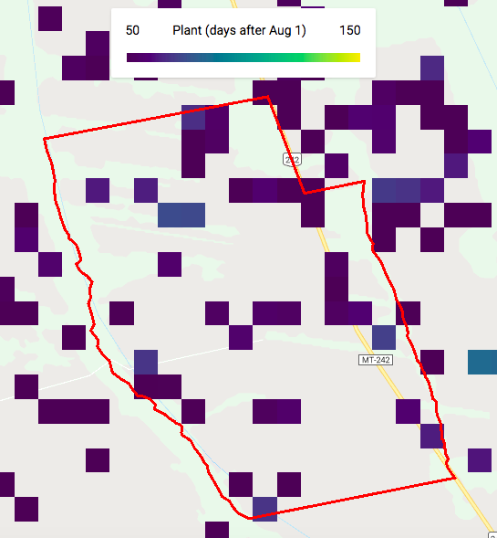

**All soy pixels in central farm in 2017:**

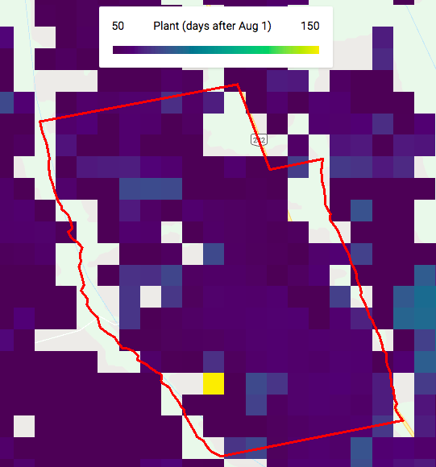

# **Timeseries of central farm and of its neighbors**

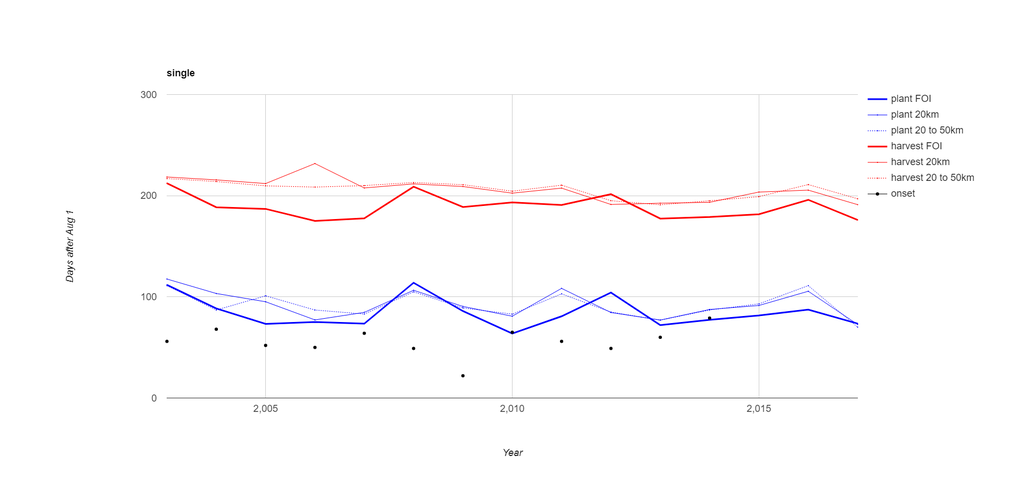

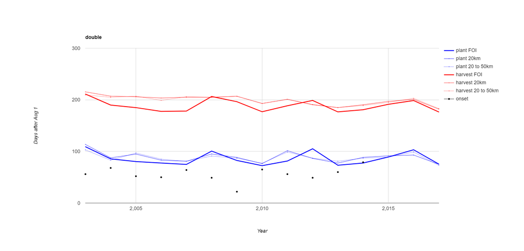

```r
library(ggplot2)
library(ggridges)
library(viridis)
specificPoly_data <- read.csv('FOI_stats.csv')
neighbors_double <- read.csv('double_50km_MT.csv')
neighbors_single <- read.csv('single_50km_MT.csv')
```

# **Histograms of neighbors with 50km of central farm**

- Red lines correspond to planting or harvest date estimate at the central farm
- Blue lines correspond to onset date (2015 to 2017 don’t have onset estimates yet)

```
Ignoring unknown aesthetics: height, fillIgnoring unknown aesthetics: height, fillIgnoring unknown aesthetics: height, fill
```

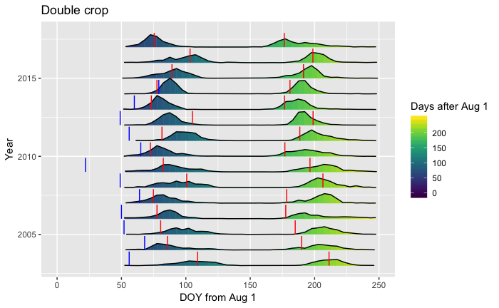

```r
# DOUBLE PLANT AND HARVEST
ggplot(neighbors_double, aes(x = neighbors_double$DOY, y = neighbors_double$Year, height = neighbors_double$Count, group = neighbors_double$Year, fill = neighbors_double$DOY)) +
  xlim(0, 250) +
  xlab("DOY from Aug 1") +
  ylab("Year") +
  ggtitle("Double crop") +
  geom_density_ridges_gradient(stat = "identity", scale = 1) +
  scale_fill_viridis(name = 'Days after Aug 1') +
  geom_segment(data = specificPoly_data, aes(x = double_plant_median, y = year, group = year, xend = double_plant_median, yend = year + 0.9, height = rep(100, 15), fill = double_plant_median), color = "red") +
  geom_segment(data = specificPoly_data, aes(x = double_harvest_median, y = year, group = year, xend = double_harvest_median, yend = year + 0.9, height = rep(100, 15), fill = double_harvest_median), color = "red") +
  geom_segment(data = specificPoly_data, aes(x = onset_median, y = year, group = year, xend = onset_median, yend = year + 0.9, height = rep(100, 15), fill = onset_median), color = "blue")
```

```r
# SINGLE PLANT AND HARVEST

ggplot(neighbors_single, aes(x = neighbors_single$DOY, y = neighbors_single$Year, height = neighbors_single$Count, group = neighbors_single$Year, fill = neighbors_single$DOY)) +
  xlim(0, 250) +
  xlab("DOY from Aug 1") +
  ylab("Year") +
  ggtitle("Single crop") +
  geom_density_ridges_gradient(stat = "identity", scale = 1) +
  scale_fill_viridis(name = 'Days after Aug 1') +
  geom_segment(data = specificPoly_data, aes(x = single_plant_median, y = year, group = year, xend = single_plant_median, yend = year + 0.9, height = rep(100, 15), fill = single_plant_median), color = "red") +
  geom_segment(data = specificPoly_data, aes(x = single_harvest_median, y = year, group = year, xend = single_harvest_median, yend = year + 0.9, height = rep(100, 15), fill = single_harvest_median), color = "red") +
  geom_segment(data = specificPoly_data, aes(x = onset_median, y = year, group = year, xend = onset_median, yend = year + 0.9, height = rep(100, 15), fill = onset_median), color = "blue")
```

[output not shown]

# **To add: maps of planting/harvest estimates for neighboring polygons**

# **Notes**

**Choosing CAR polygons ‘of interest’**

- In MT, a polygon that coincided with Rally point and Dave’s sample point and that also was consistently planted from 2003 to 2017
- In Matopiba, a polygon that coincided with Dave’s sample point, a Matopiba survey point that had consistent reported data over the Matopiba survey years

**Filtering CAR polygons**

Used only polygons with:

- Total area > 2 km2
- Planted : total area ratio > 20%
- Planting between 50 and 150 and harvest between 150 and 250 days after Aug 1